# Example Analysis

Anna Bird

12.02.21

##### Purpose of the script: demonstrate coding skills using *in silico*-generated (non-proprietary) flow cytometry data

##### How to use this script

1. run the script Ctrl+Alt+R
2. Click “Preview” button above to see HTML Analysis Report

##### Script Inputs

- “example FACS data.xlsx” This includes raw data & metadata for the FACS experiment

##### Script Outputs

- Report output from this .Rmd ________________Primary Analysis (cf “How to use this script”)
- “antigen responses to drug treatments.pdf” __________ Supplementary exported plots
- “120901 FACSstats CleanedMerged.xlsx” __________ exported tidied data set

### Script Title: Assessing the efficacy of several compounds to improve the maturation & function of Cell Type X

### Experimental Question: How does treatment with drugs A-D affect differentiation of Cell Type X?

- In healthy human peripheral blood, antigens A & B indicate mature & immature forms of Cell Type X, respectively
- Problem: In disease, there is a defect in maturation of Cell Type X, and therapeutic intervention is needed to induce maturation of Cell Type X
- Goal: Assess the capacity of drug stimuli A, B, C, & D to induce maturation, as measured by FACS immunophenotyping

### Goal 1: Assess which functional markers appear with drug-induced maturation of cell type X

- Antigen A indicates advanced maturation of Cell Type X
- Antigen B indicates immature cell status

### Goal 2: Determine how drug combinations affect the essential cell functions performed by Antigens C - I

- Antigens C - I are functional markers associated with effector function of mature Cell Type X in healthy individuals.

### Experimental Setup

##### 1) Isolated immature cell type X from patients with disase and treated cells w/ drug stims A - D for 48 hrs @37degreesC

##### 2) Stained cells with antibodies against Antigens A - I

##### 3) Ran flow cytometry to visualize the phenotypic relationships of multiple cell type X treatment groups.

### Analysis Results

[output not shown]

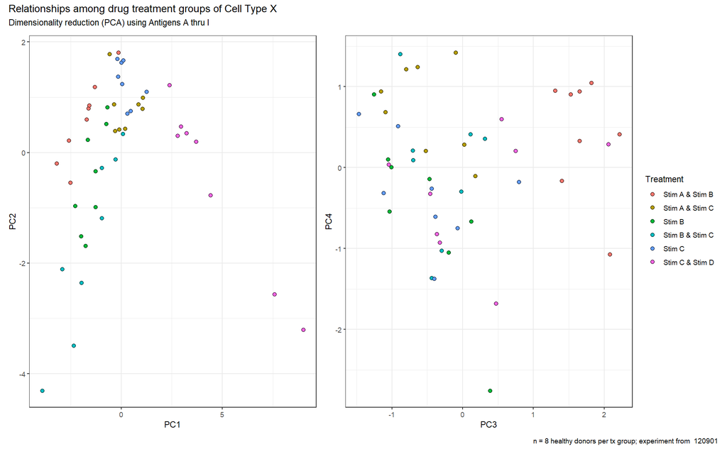

#### The PCA plot (PC1 x PC2) above suggests a possible differentiation path of Cell Type X.

This hypothesis can be confirmed by asking which treatment group expresses the highest level of Antigen A (maturation marker)?

[output not shown]

[output cut: 35 more lines]

[output not shown]

[figure not shown]

#### Conclusions:

- The principal components (PC1xPC2) dot plot above shows a differentiation path. The bar chart above shows that Stim C & D yields the most immature state of Cell Type X, & Stims B & C showing the greatest degree of maturation of Cell Type X

#### Does drug-induced maturation generate full effector function?

#### Which cell functional markers may be defective with drug-induced maturation?

- The differentiation path of Cell Type X is most clearly observable in PC1 & PC2.
- Several antigens indicate fully developed effector function, including Antigens C, D, G, I, & J
- Which functional markers (Antigens C-I) are most strongly associated with drug-induced maturation?

#### Plotting the PCA loadings to determine which functional antigens are most strongly associated with maturation path seen in PC1 & PC2.

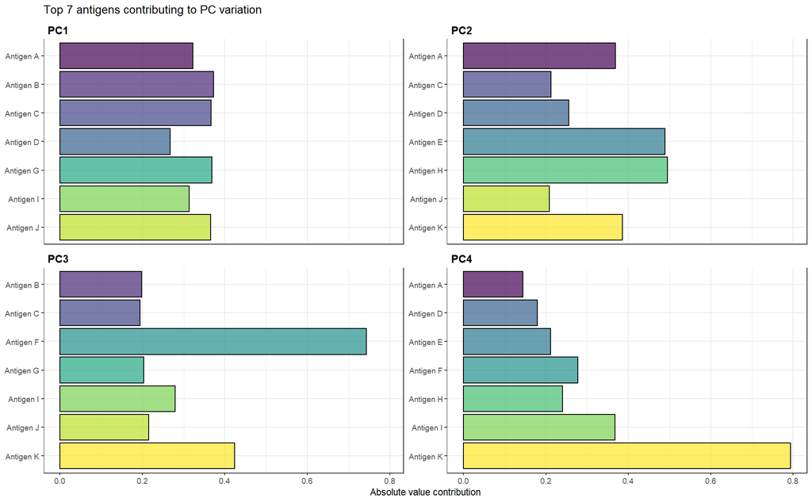

### In summary, the analysis finds that therapeutic treatment with drugs B & C can induce partial maturation of Cell Type X

- 48 hour treatment with drug stims B & C showed the strongest induction of classic markers of maturation (eg Antigen A).
- Cell Type X treated with drugs B & C show some, but not all functional markers typically associated with maturation (Antigens C - I).